# Grade 3 Data

Makayla Whitney, Joe Nese

1/21/2021

# Results

## Grade 3

### **Student Figures**

**The below figures are representative of 3rd grade student scores. Please refer back to these figures when observing the data collected from teacher surveys.**

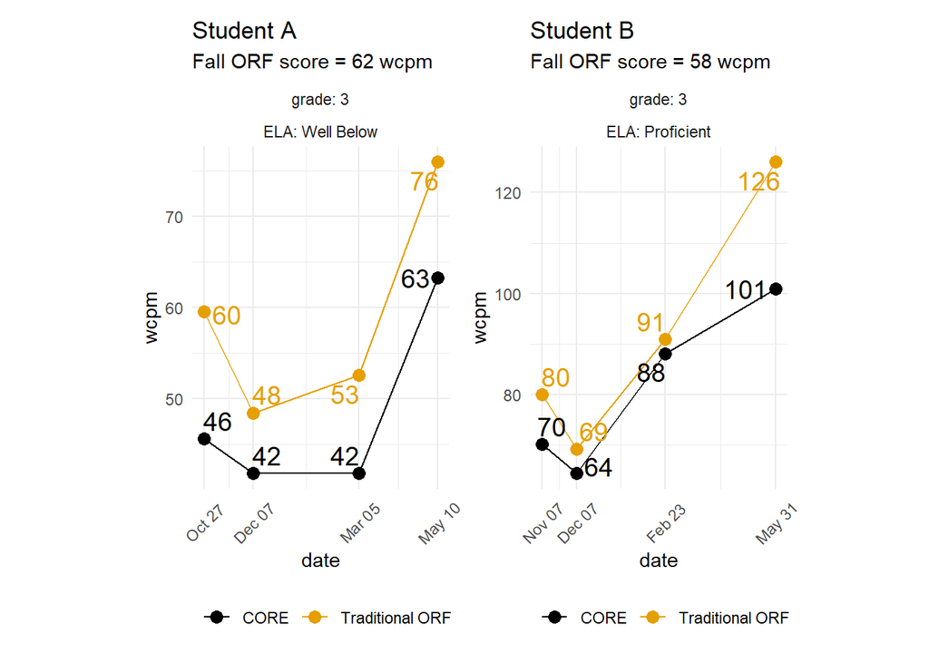

[figure not shown]

#### **Reading Level**

##### **Based on the fall ORF score, the student is reading:**

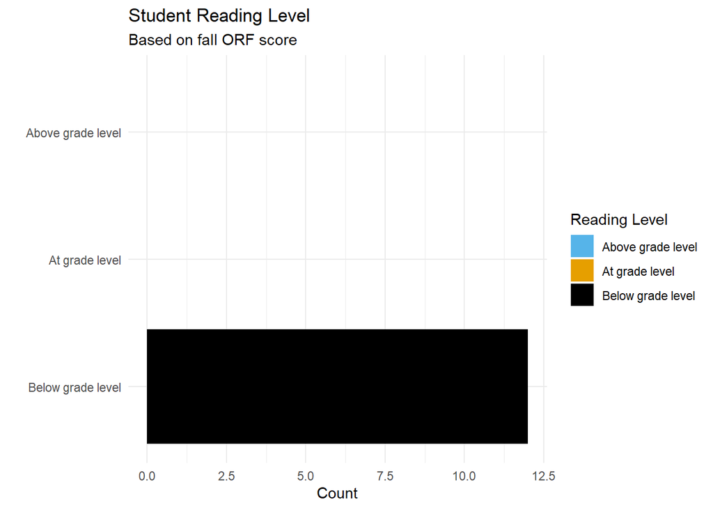

##### **Below are descriptions of the student’s reading level based on fall ORF score alone.**

| **Teacher** | **ORF** | **Response** |
| --- | --- | --- |
| Student A |  |  |
| Teacher 1 | 62 | A score of 62 WCPM would put this student is in a category of 'some risk'. This student is at approximately the 25%ile. |
| Teacher 2 | 62 | This student is reading at a rate that is below the third-grade level. Not much else can be detected from this number. |
| Teacher 3 | 62 | Below level, probably qualifying for reading interventions. |
| Student B |  |  |
| Teacher 1 | 58 | This student is would be considered high risk. |
| Teacher 2 | 58 | The student is reading below grade level. |
| Teacher 3 | 58 | Below level. |
| Student C |  |  |
| Teacher 1 | 48 | This student is at high risk scoring at approximately the 10th %ile. |
| Teacher 2 | 48 | Struggling reader in need of support. |
| Teacher 3 | 48 | Well below level. |
| Student D |  |  |
| Teacher 1 | 51 | High Risk |
| Teacher 2 | 51 | Struggling reader. |
| Teacher 3 | 51 | Well below level. |

#### **At Risk?**

##### **Is this student at risk of poor reading outcomes?**

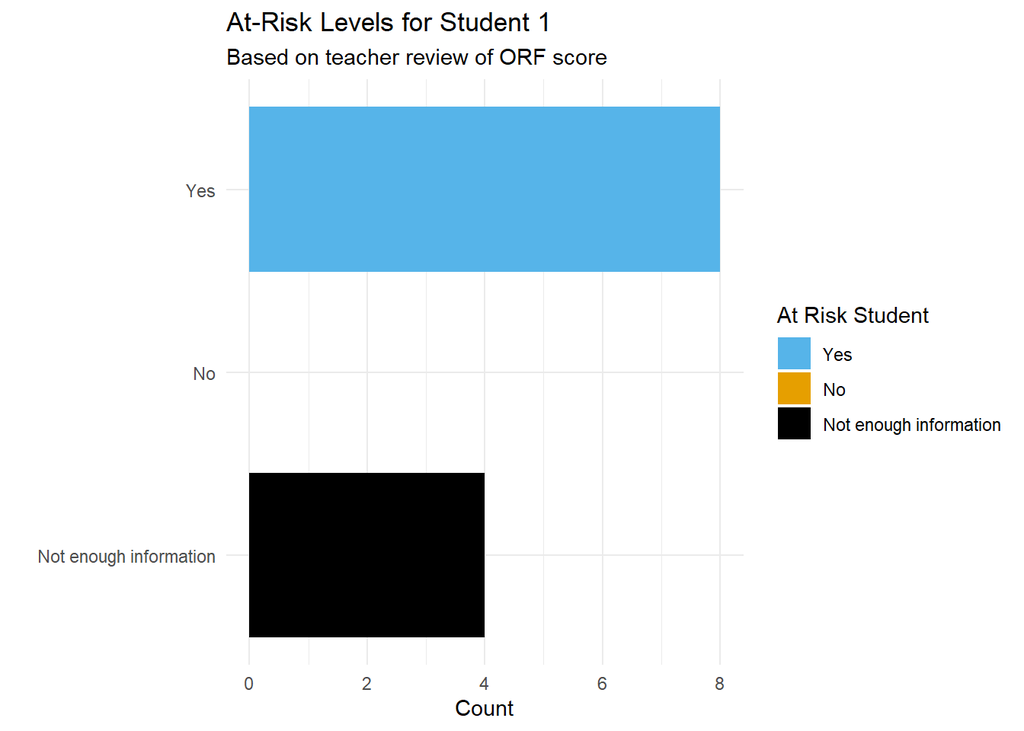

##### **If you answered “not enough information,” please specify what other data you would like to see for this student.**

| I would like to see a phonics/decoding screener to determine if the fluency rate is lower because of decoding issues. |
| --- |
| Without hearing the passage being read, one can not determine where the child has difficulty. Nor is there any evidence of comprehension. Even a slow reader can indicate comprehension with intonations… |
| How often does the child pause and for how long. |
| I would want to listen to hear what needs to be addressed. Is it word attack, vocabulary, nerves, or basic sight-words. |

**Results:** Many teachers believe these students are at risk of poor reading outcomes. When asked to further explain, many teachers felt they didn’t have enough information. To make a conclusive decision about the student, teachers would need to either hear a recording of the student or watch the student read aloud. This would improve their knowledge of the student’s decoding skills, reading pace, and pausing habits.

#### **Progress Monitoring**

##### **Which line might be better for progress monitoring? And why?**

|  |  | **Why?** |
| --- | --- | --- |
| I don't know |  |  |
| Student A | Teacher 2 | There is not enough information. Both show a drop prior to improvement. |
| Student C | Teacher 2 | I am not sure I even understand these questions. Is it to measure the effectiveness of interventions, or the need for taking a closer look at what interventions are in place and what needs to be chang… |
| Student D | Teacher 2 | Not enough information. |
| No difference between the two lines |  |  |
| Student A | Teacher 1 | Both lines show an initial decline and then a flatline for 3 months. |
| Student B | Teacher 1 | Both students need progress monitored as they are below the 50th %ile through February. Interventions seem to be working. |
| Student C | Teacher 1 | Both students are below grade level all year. |
| Student D | Teacher 1 | Both students will benefit from intervention and progress monitoring will help drive those decisions. |
| Student B | Teacher 2 | They both only show data points. |
| Student A | Teacher 3 | While they have different start points they are directionally the same. Student starts the year well below level on both. The trend lines track between both lines. Fortunately the student ends the yea… |
| Student B | Teacher 3 | Both lines are tracking similarly. Student is showing very positive growth in both. |
| Student C | Teacher 3 | Both show a similar trend in the students reading progress. |
| Student D | Teacher 3 | Both show similar trend of positive reading growth. |

**Results:** For most of the plots, teachers agreed that there was little difference between the two lines. Common aspects pointed out included slow progress and similar direction.

#### **Trustworthy Trajectory**

##### **Based on the trajectory of the lines - that is, the shape of the lines - which line might be more trustworthy? And why?**

|  |  | **Why?** |
| --- | --- | --- |
| CORE (Black) |  |  |
| Student A | Teacher 1 | The initial drop of the yellow line seems as though there could be other circumstances involved, such as the child not feeling well. |
| Student C | Teacher 1 | The sharp decline from November to December on the yellow line seems like an anomaly. |
| Student D | Teacher 1 | The huge discrepancy from the first two data point and the last two of the yellow line seems unreliable. There had to be some factor for the student testing so low in the fall. |
| I don't know |  |  |
| Student A | Teacher 2 | There is not enough information. |
| Student B | Teacher 2 | They only show data points. Not enough information. |
| Student D | Teacher 2 | Not enough information. |
| No difference between the two lines |  |  |
| Student A | Teacher 3 | The progress tracks the same between both. |
| Student B | Teacher 1 | Both students are in an upward trajectory making progress. |
| Student B | Teacher 3 | They are tracking similarly. |
| Student C | Teacher 2 | These are data points only. Without a student to listen to, there is not enough to go on. |
| Student C | Teacher 3 | Both show a similar trend in the students reading progress. |
| Student D | Teacher 3 | Both show similar trend of positive reading growth. |

**Results:** While most teachers noted the lack of difference between lines, a few stated that the CORE line appears to be more trustworthy. They pointed out that the sharp decline in the ORF (Yellow) line may be due to extenuating circumstances unknown to them.

#### **Intervention Working?**

[figure not shown]

##### **Let’s say the figure shows data of a student receiving a reading intervention. For the Traditional ORF (*YELLOW*) line, look at the first three data points only (ignore the last data point from May or June). What might you say about the intervention? And why?**

|  | Teacher |  |
| --- | --- | --- |
| I cannot tell whether the intervention is working or not |  |  |
| Student Student A | Teacher 2 | Although there was an initial drop, and a slight rise after, without the next point it's not clear whether the child was helped by interventions. |
| Student Student B | Teacher 2 | The graph seems to show an increase in the student's reading rate only. Fluency is more complicated. Gains are made through class/whole group work as well, where we work on expression and the author's… |
| Student Student C | Teacher 2 | The upward trajectory looks good. However, I would need to listen to the child. |
| It appears the intervention is NOT working for the student |  |  |
| Student Student A | Teacher 1 | There is little to no gain in fluency. |
| Student Student A | Teacher 3 | The student's reading scores are tracking down. |
| It appears the intervention is working for the student |  |  |
| Student Student B | Teacher 1 | The student is making fluency gains. |
| Student Student B | Teacher 3 | The third data point shows great improvement. |
| Student Student C | Teacher 1 | Although the student shows a decline in the first month, there is an upward trajectory from Dec. - March. |
| Student Student C | Teacher 3 | The third data point shows strong positive reading growth. |
| Student Student D | Teacher 1 | There was a huge gain. |
| Student Student D | Teacher 2 | The trajectory is upward. |
| Student Student D | Teacher 3 | Student may huge reading growth gains by the third data point. |

##### **Let’s say the figure shows data of a student receiving a reading intervention. For the CORE (*BLACK*) line, look at the first three data points only (ignore the last data point from May or June). What might you say about the intervention? And why?**

|  | Teacher |  |
| --- | --- | --- |
| I cannot tell whether the intervention is working or not |  |  |
| Student Student A | Teacher 2 | Listening is how we can tell how the student is reading. The numbers alone don't indicate where the difficulties lie. One thing that students are coached on is punctuation and how to read what the aut… |
| Student Student B | Teacher 1 | The student is making gains, but not at the rate I would like to see. |
| Student Student B | Teacher 2 | The graph seems to show an increase in the student's reading rate only. Fluency is more complicated. Gains are made through class/whole group work as well, where we work on expression and the author's… |
| Student Student C | Teacher 2 | I need to listen to the child. That is how I diagnose. |
| It appears the intervention is NOT working for the student |  |  |
| Student Student A | Teacher 1 | There is little to no gain in fluency. |
| Student Student A | Teacher 3 | The scores are tracking down. |
| Student Student C | Teacher 1 | Little to no progress is being made. |
| It appears the intervention is working for the student |  |  |
| Student Student B | Teacher 3 | The third data point shows great improvement. |
| Student Student C | Teacher 3 | The third data point shows positive reading growth. |
| Student Student D | Teacher 1 | Steady increase |
| Student Student D | Teacher 2 | Improvement is evident in increase, but more information is needed. |
| Student Student D | Teacher 3 | Student may huge reading growth gains by the third data point. |

**Results:** Teachers across the board agreed that the intervention is working for student D based on the data displayed. Teachers believed that the intervention was either not working or they were unable to interpret the data for student A. Students B and C were also difficult for teachers to interpret, but overall they displayed an understanding that the intervention was working. If teachers were unable to tell whether the intervention was working or not, they stated the need to listen to the student in order to diagnose their progress.

#### **State Reading Test Score**

##### **Which line might better correspond with the SBAC performance level?**

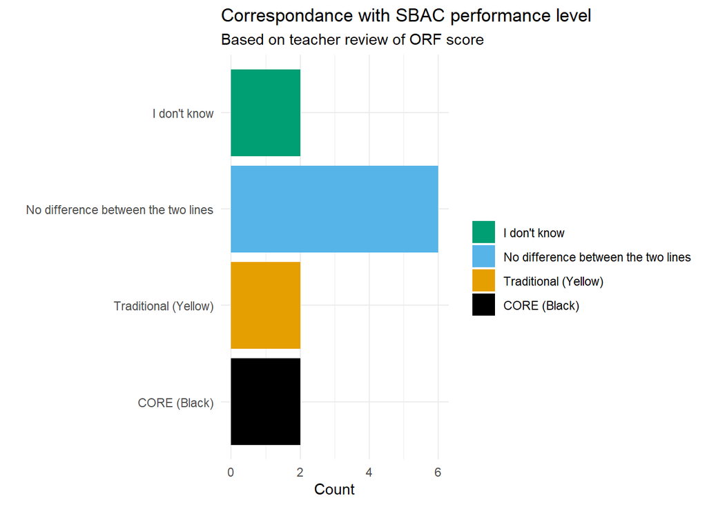

##### **Based on the last data point from *May or June* ONLY, which point might better match what you expect from a student at this SBAC performance level?**

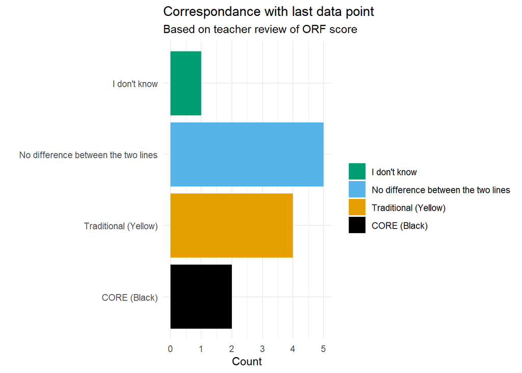

##### **Based on the first data point from *October or November* ONLY, which point might better match what you expect from a student at this SBAC performance level?**

[figure not shown]

**Results:** Neither line corresponded better with the SBAC performance level. For both the first and last data points, many teachers noted the lack of difference between lines displayed. Those that did observe a difference found the ORF (Yellow) line to correspond more effectively in both circumstances.

### **Student Figures with Measurement Error**

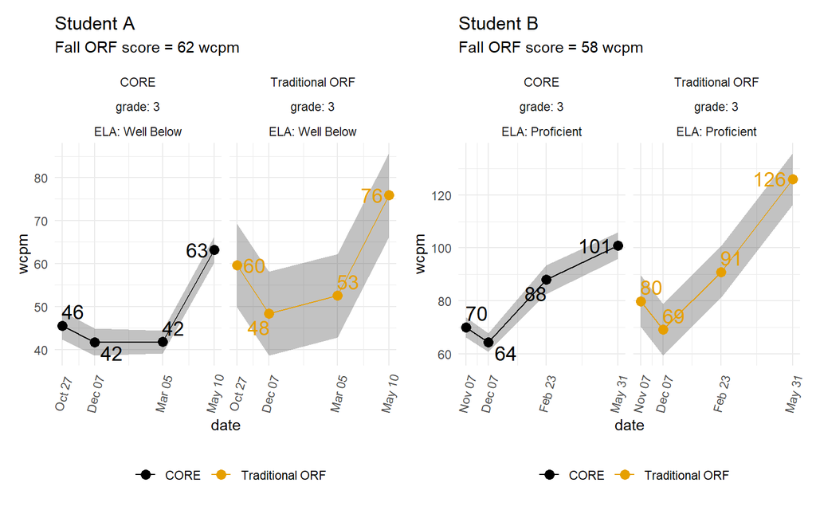

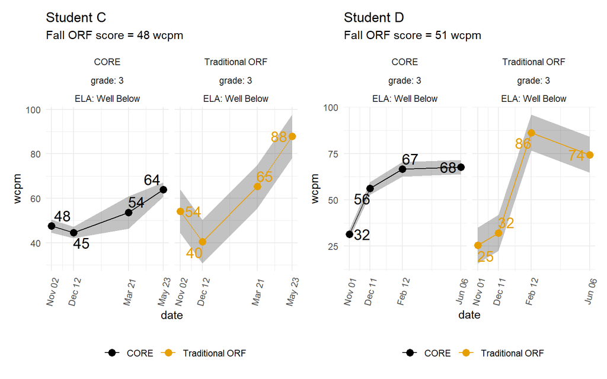

#### **Progress Monitoring and Data-Based Decisions**

##### **Which line might be better for progress monitoring and data-based decisions?**

[output not shown]

#### **Measurement Error Useful?**

##### **Does the shaded area in the graphs give you useful information if you were using the graphs to make data-based decisions?**

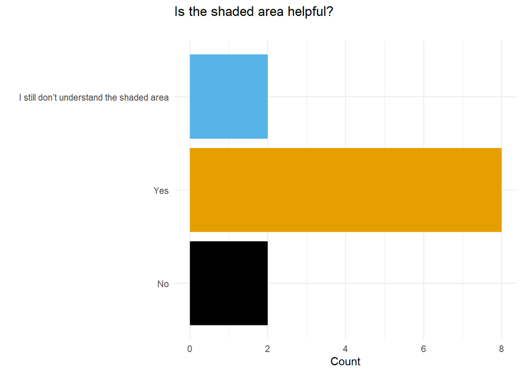

#### **How might you use this figure to make a data-based decision?**

|  | Response |
| --- | --- |
| Student A |  |
| Teacher 1 | The student with a greater measurement error may need different accommodations when testing. |
| Teacher 2 | I wouldn't, I would listen to the student reading a passage. |
| Teacher 3 | The results from both lines fall within their counterparts shaded areas, increasing my confidence of how the student's reading is truly doing. |
| Student B |  |
| Teacher 1 | Even though the yellow graph shows a greater measurement error, this student is making adequate progress. The student with the black graph definitely benefits from progress monitoring. |
| Teacher 2 | It would allow me to identify the student I would want to read with first and see where I need to target our learning. But these numbers are only numbers. There is never enough information. |
| Teacher 3 | The student may be only borderline proficient and based on the gray area might want to be assigned to a slightly lower level reading group if groups are being used. |
| Student C |  |
| Teacher 1 | The yellow student may need other accommodations when testing. |
| Teacher 2 | I would use it to indicate that I need to check in with the student to listen, coach, and encourage. |
| Teacher 3 | Shows the range of where the student might really be at. |
| Student D |  |
| Teacher 1 | The black line shows a minimal measurement error. |
| Teacher 2 | Let it guide me to take a closer look at a student's performance. |
| Teacher 3 | It shows where the reading range might be for the student. |

**Results:** A majority of teachers stated that the shaded area was helpful when observing the data. Common applications of the measurement error included early identification, understanding the range a student falls within, and as a guide for implementing assistance in the future.